# DSC4217 Report

# 1 Background

The Godfather Capital Group is an American investment company that has been actively involved in the stock market since its establishment in 1990. Survived through two devastating financial crisis in 1997 and 2008 through applying diversification strategy in stock selection, the company is proud of its risk management techniques.

However, In 2018,the Dow fell 5.6%. The S&P 500 was down 6.2% and the Nasdaq fell 4%. It was the worst year for stocks since 2008. The CEO of the firm, Jiang Tao is worried about a possible upcoming crisis in the stock market and thus wants to further diversify the company’s investment portfolio by entering into the movie industry.

[figure not shown]

As such, a new functional team named ‘DSC4217’ team has benn formed to carry out research and data analysis for this new line of investment. After some initial analysis, the group noticed the following findings:

1. The average movie production cost is around $65 million, while the follow-up marketing and distribution is around $35 million. In total, the cost to product a movie is at $100 million.
2. Film has a reputation of being highly risky and only a very small number become blockbusters.

In conclusion, the large volume of investment required and the high risk embedded makes investment in movie industry highly risky. Thus, to better assess the risk associated with each production candidate, the team aims to build a classification model as well as a regression model to to forecast the likelihood of profiting from the investment and the volume of the profits respectively.

**Some additional information:**

1. As it is an American company and majority of its employees only understand English, the company only wants to invest in English-Language movie.
2. The company CFO,Run, is a die hard fan for Bruce Lee and has strong passion in action movies. Unless model shows otherwise, Run will only permits fund request for investment in action movies.

# 2 Data Source

The data used in this report were obtained from two sources for the time period 1980 to 2016, 5000 movie entries from IMDB while the average ticket price is sourced from the Box Office Mojo website.

## 2.1 Data Variable

The IMDB data came with 5000 entries with 29 variables (14 numerical variables and 15 categorical variables). The yearly prices and number of movies realeased yearly were added from Box Office Mojo.

```r
#variables <- read.csv("./data variables.csv")
#kable(variables,caption="List of variables")
```

## 2.2 Data Preperation

# 3 Classification

```r
#load library
library(caret)
```

```r
library(ggplot2)
library(rpart)
library(randomForest)
library(rpart.plot)
library(grid)
library(mvtnorm)
library(modeltools)
library(stats4)
library(strucchange)
library(zoo)
library(party)
#load cleaned data
dataset <-read.csv('C:/Users/Linh/Documents/Y3 Sem 2/DSC4217/Group Project/New data cleaned/imdb_cleaned.csv')
dataset$profitability <- as.factor(dataset$profitability)
```

Predictor variables we have choosen for the classification model are X1: num_critic_for_reviews X2: duration X3: director_facebook_likes X4: num_voted_users X5: cast_total_facebook_likes (for 3 casts, and each missing individual cast is filled with average value) X6: num_user_for_reviews X7~X29(Use action as baseline): Action, Adventure, Animation, Biography, Comedy, Crime, Documentary, Drama, Family, Fantasy, History, Horror, Music, Musical, Mystery, Romance, Sci.Fi,Sport,Thriller,War,Western X30: # ofMovies X31: Avg.Ticket Price X32: Content_rating X33: Budget X34: imdb_score

```r
#Subseting dataset with chosen dependent and predictor variables
dataset1<-dataset[,c(53,5,6,7,14,15,19,27:51,22,23,25)]
head(dataset1)
```

```
##   profitability num_critic_for_reviews duration director_facebook_likes
## 1             1                    121      104                969.8093
## 2             1                    121      116                 44.0000
## 3             1                     71       98              11000.0000
## 4             0                     26      124                 42.0000
## 5             0                    102      325                517.0000
## 6             1                    125      148                644.0000
##   num_voted_users cast_total_facebook_likes num_user_for_reviews Action
## 1           23986                      1838                  201      0
## 2           76331                      1480                  269      1
## 3           81599                     14057                  250      0
## 4            2998                      1136                   74      0
## 5            9830                     13527                  189      0
## 6          142448                      2135                  319      1
##   Adventure Animation Biography Comedy Crime Documentary Drama Family
```

[output cut: 27 more lines]

```r
table(dataset1$profitability)
```

```
##
##    0    1
## 1643 1876
```

In order to validate our model, we split the dataset into two sets, training dataset (80%) and testing dataset (20%).

```r
set.seed(1234)
sample <- sample(c(TRUE,FALSE),nrow(dataset1),prob = c(0.8,0.2),replace = TRUE)
movie.train <- dataset1[sample, ]
movie.test <- dataset1[!sample, ]
```

### 3.0.1 K-forld classification

To ensure accuracy, we use 5-fold cross validation to make sure that our model is relatively stable and not overfitting. Therefore, the accuracy when testing against 5 folds will be taken into consideration when choosing the final model.

```r
set.seed(123)
train_control <- trainControl(method="cv", number=5,savePredictions = TRUE)#,summaryFunction=defaultSummary(trainData,trainData$DELAY))
```

## 3.1 Model 1: Classical decision tree

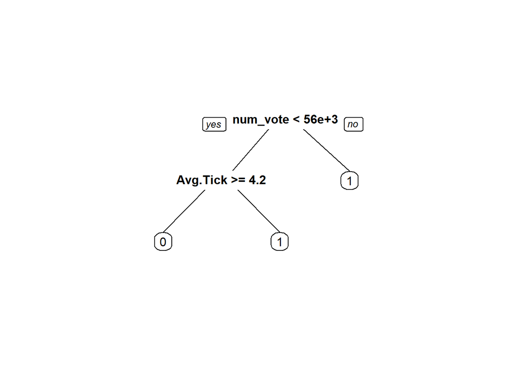

```r
#classification tree
#classtree <- train(profitability~., data=movie.train, trControl=train_control, method="rpart")
#saveRDS(classtree, file = "C:/Users/Linh/Documents/Y3 Sem 2/DSC4217/Group Project/New data cleaned/classtree.rds")
classtree<-readRDS("C:/Users/Linh/Documents/Y3 Sem 2/DSC4217/Group Project/New data cleaned/classtree.rds")
library(rpart.plot)
prp(classtree$finalModel)            #plot the final tree model
```

```r
print(classtree)                                    #print tree performance
```

```
## CART
##
## 2818 samples
##   34 predictor
##    2 classes: '0', '1'
##
## No pre-processing
## Resampling: Cross-Validated (5 fold)
## Summary of sample sizes: 2255, 2255, 2254, 2254, 2254
## Resampling results across tuning parameters:
##
##   cp          Accuracy   Kappa
##   0.01635514  0.6678615  0.3282420
##   0.03660436  0.6557878  0.3102618
##   0.24376947  0.6007741  0.1670376
##
## Accuracy was used to select the optimal model using the largest value.
## The final value used for the model was cp = 0.01635514.
```

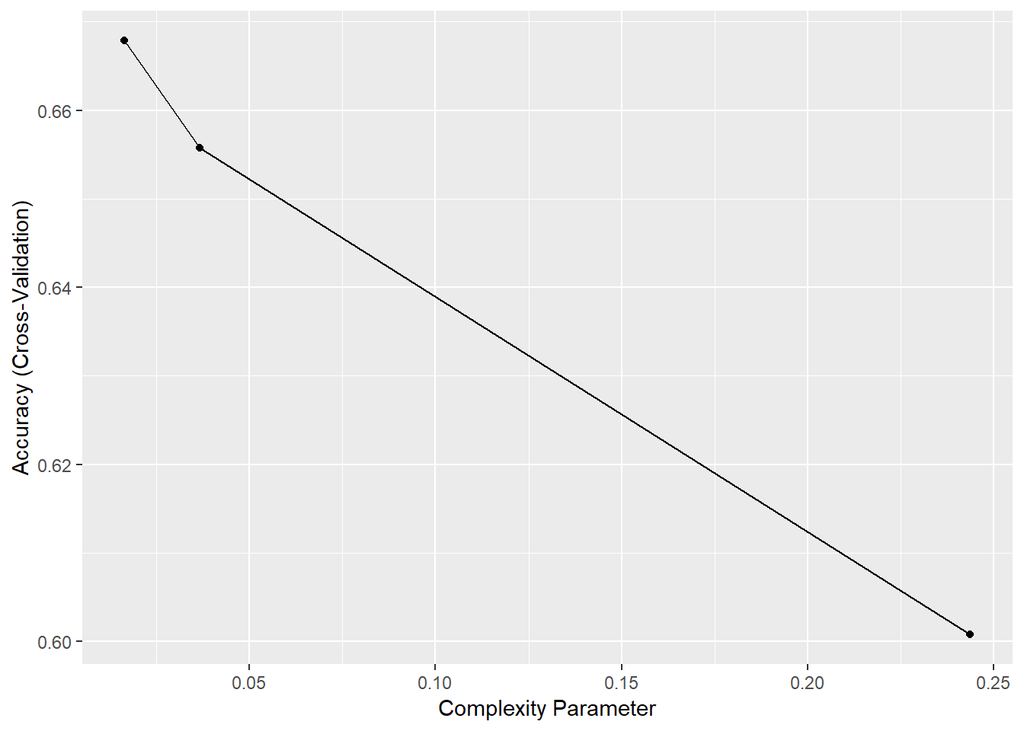

```r
ggplot(classtree)                                   #plot tree performance
```

Indeed, cp of 0.01635514 is chosen as increasing complexity parameter leads to lower accuracy.

```r
classtree$resample                                  #reporting each fold performance
```

```
##    Accuracy     Kappa Resample
## 1 0.6802842 0.3647908    Fold1
## 2 0.6891652 0.3680609    Fold2
## 3 0.6808511 0.3386233    Fold5
## 4 0.6382979 0.2736272    Fold4
## 5 0.6507092 0.2961076    Fold3
```

```r
#Confusion matrix with test data
cm1<-as.matrix(table(predict(classtree,movie.test),movie.test$profitability))
cm1
```

```
##
##       0   1
##   0 226 123
##   1 133 219
```

```r
#Calculating
accuracy11<-(cm1[1,1]+cm1[2,2])/(cm1[1,1]+cm1[2,2]+cm1[1,2]+cm1[2,1])
accuracy11
```

```
## [1] 0.6348074
```

```r
#Confusion matrix with train data
cm2<-as.matrix(table(predict(classtree,movie.train),movie.train$profitability))
cm2
```

```
##
##        0    1
##   0  855  495
##   1  429 1039
```

```r
accuracy12<-(cm2[1,1]+cm2[2,2])/(cm2[1,1]+cm2[2,2]+cm2[1,2]+cm2[2,1])
accuracy12
```

```
## [1] 0.6721079
```

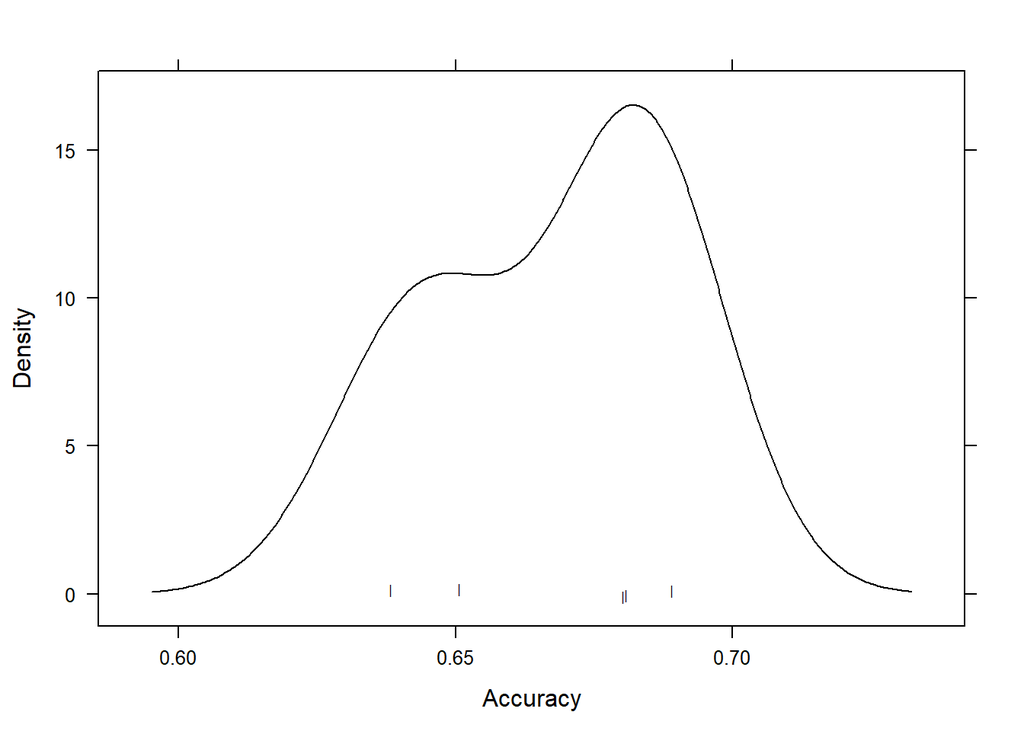

```r
trellis.par.set(caretTheme())
densityplot(classtree, pch = "|")                   #density plot
```

## 3.2 Model 2: Conditional Inference Classification tree

```r
#classification tree
#classtree1 <- train(profitability~., data=movie.train, trControl=train_control, method="ctree")
#saveRDS(classtree1, file = "C:/Users/Linh/Documents/Y3 Sem 2/DSC4217/Group Project/New data cleaned/classtree1.rds")
classtree1<-readRDS("C:/Users/Linh/Documents/Y3 Sem 2/DSC4217/Group Project/New data cleaned/classtree1.rds")
```

[figure not shown]

```r
plot(classtree1$finalModel)            #plot the final tree model
```

```r
print(classtree1$finalModel)
```

```
##
##   Conditional inference tree with 121 terminal nodes
##
## Response:  .outcome
## Inputs:  num_critic_for_reviews, duration, director_facebook_likes, num_voted_users, cast_total_facebook_likes, num_user_for_reviews, Action, Adventure, Animation, Biography, Comedy, Crime, Documentary, Drama, Family, Fantasy, Film.Noir, History, Horror, Music, Musical, Mystery, Romance, Sci.Fi, …
## Number of observations:  2818
##
## 1) num_voted_users <= 56005; criterion = 1, statistic = 226.931
##   2) num_voted_users <= 3875; criterion = 1, statistic = 32.522
##     3) budget <= 5e+05; criterion = 0.921, statistic = 9.535
##       4) num_user_for_reviews <= 23; criterion = 0.972, statistic = 11.493
##         5) num_user_for_reviews <= 13; criterion = 0.134, statistic = 3.918
##           6) X..ofMovies <= 607; criterion = 0.198, statistic = 4.274
##             7)*  weights = 9
##           6) X..ofMovies > 607
##             8)*  weights = 12
##         5) num_user_for_reviews > 13
##           9)*  weights = 10
##       4) num_user_for_reviews > 23
##         10)*  weights = 12
##     3) budget > 5e+05
##       11) Avg.TicketPrice <= 6.03; criterion = 0.768, statistic = 7.433
##         12) budget <= 1e+07; criterion = 0.325, statistic = 4.888
##           13) Avg.TicketPrice <= 4.59; criterion = 0.589, statistic = 6.193
##             14)*  weights = 14
##           13) Avg.TicketPrice > 4.59
##             15) imdb_score <= 5; criterion = 0.969, statistic = 11.295
##               16)*  weights = 7
##             15) imdb_score > 5
##               17)*  weights = 28
##         12) budget > 1e+07
##           18)*  weights = 31
##       11) Avg.TicketPrice > 6.03
##         19) Romance <= 0; criterion = 0.042, statistic = 18
##           20)*  weights = 63
##         19) Romance > 0
##           21)*  weights = 13
##   2) num_voted_users > 3875
##     22) budget <= 3.3e+07; criterion = 1, statistic = 44.497
##       23) num_user_for_reviews <= 253; criterion = 1, statistic = 25.649
```

[output cut: 313 more lines]

```
##         232) budget <= 9.2e+07; criterion = 0.913, statistic = 9.365
##           233) Sci.Fi <= 0; criterion = 0.046, statistic = 3.231
##             234)*  weights = 77
##           233) Sci.Fi > 0
##             235)*  weights = 16
##         232) budget > 9.2e+07
##           236)*  weights = 16
##     225) Comedy > 0
##       237) Fantasy <= 0; criterion = 0.017, statistic = 7.352
##         238) Crime <= 0; criterion = 0.216, statistic = 4.364
##           239)*  weights = 48
##         238) Crime > 0
##           240)*  weights = 11
##       237) Fantasy > 0
##         241)*  weights = 20
```

For example, given the number of voted users > 244566, the movie is more likely to be profitable with Comedy genre combined with Fantasy genre.

```r
print(classtree1)                                    #print tree performance
```

```
## Conditional Inference Tree
##
## 2818 samples
##   34 predictor
##    2 classes: '0', '1'
##
## No pre-processing
## Resampling: Cross-Validated (5 fold)
## Summary of sample sizes: 2256, 2254, 2254, 2254, 2254
## Resampling results across tuning parameters:
##
##   mincriterion  Accuracy   Kappa
##   0.01          0.6927160  0.3802329
##   0.50          0.6898690  0.3744480
##   0.99          0.6802895  0.3521084
##
## Accuracy was used to select the optimal model using the largest value.
## The final value used for the model was mincriterion = 0.01.
```

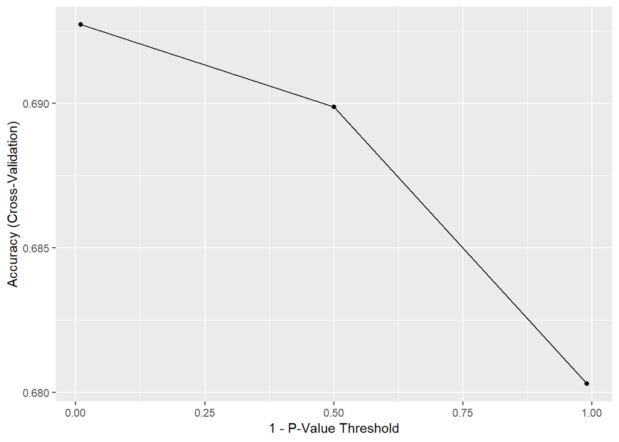

```r
ggplot(classtree1)                                   #plot tree performance
```

```r
classtree1$resample                                  #reporting each fold performance
```

```
##    Accuracy     Kappa Resample
## 1 0.7295374 0.4582171    Fold1
## 2 0.6790780 0.3561319    Fold4
## 3 0.6879433 0.3705437    Fold3
## 4 0.6666667 0.3220374    Fold2
## 5 0.7003546 0.3942344    Fold5
```

```r
#Confusion matrix with test data
cm1<-as.matrix(table(predict(classtree1,movie.test),movie.test$profitability))
cm1
```

```
##
##       0   1
##   0 248  93
##   1 111 249
```

```r
#Calculating accuracy rate
accuracy21<-(cm1[1,1]+cm1[2,2])/(cm1[1,1]+cm1[2,2]+cm1[1,2]+cm1[2,1])
accuracy21
```

```
## [1] 0.7089872
```

```r
#Confusion matrix with train data
cm2<-as.matrix(table(predict(classtree1,movie.train),movie.train$profitability))
cm2
```

```
##
##        0    1
##   0 1021  236
##   1  263 1298
```

```r
#Calculating accuracy rate
accuracy22<-(cm2[1,1]+cm2[2,2])/(cm2[1,1]+cm2[2,2]+cm2[1,2]+cm2[2,1])
accuracy22
```

```
## [1] 0.8229241
```

From the confusion matrices, we can conclude that the model perform quite well with the training dataset (82% accuracy) and not as well with the testing dataset (71% accuracy).

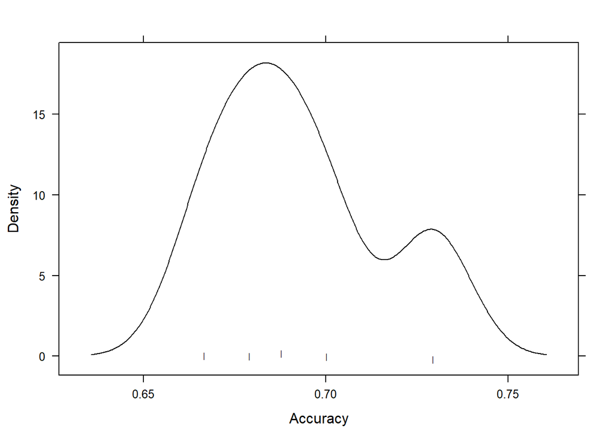

```r
trellis.par.set(caretTheme())
densityplot(classtree1, pch = "|")                   #density plot
```

Generally the accuracy usually falls at around 69% with the distribution shown as above.

## 3.3 Model 3: Log regression model

```r
#classlogit <- train(profitability~., data=movie.train, trControl=train_control, method="glmStepAIC")
#saveRDS(classlogit, file = "C:/Users/Linh/Documents/Y3 Sem 2/DSC4217/Group Project/New data cleaned/classlogit.rds")
classlogit<-readRDS("C:/Users/Linh/Documents/Y3 Sem 2/DSC4217/Group Project/New data cleaned/classlogit.rds")
```

```r
print(classlogit$finalModel)                        #print the final logit model
```

```
##
## Call:  NULL
##
## Coefficients:
##               (Intercept)     num_critic_for_reviews
##                 1.109e+00                  2.919e-03
##                  duration    director_facebook_likes
##                -7.673e-03                 -4.078e-05
##           num_voted_users                  Biography
##                 1.224e-05                 -2.743e-01
##                    Comedy                Documentary
##                 3.055e-01                  8.100e-01
##                     Drama                     Family
##                -2.136e-01                  7.863e-01
##                   Fantasy                     Horror
##                -5.651e-01                  7.865e-01
##                     Music                    Romance
##                 3.879e-01                  1.998e-01
##                    Sci.Fi                      Short
##                -9.496e-01                  1.393e+01
##               X..ofMovies            Avg.TicketPrice
##                 2.973e-03                 -4.697e-01
##        content_ratingMiss      `content_ratingNC-17`
##                -2.680e+00                 -2.152e+00
## `content_ratingNot Rated`           content_ratingPG
##                -1.786e+00                  4.089e-01
##           content_ratingR      content_ratingUnrated
##                -6.268e-01                 -1.211e+00
##                    budget                 imdb_score
##                -1.817e-08                  1.114e-01
##
## Degrees of Freedom: 2817 Total (i.e. Null);  2792 Residual
## Null Deviance:       3884
## Residual Deviance: 3096  AIC: 3148
```

It is recognizable that genres such as Comedy, Documentary, Family, Horror, Romanc, Short and Music are positively correlated with profitability. Also, content rating PG is recommended as it is also positively correlated with profitability. IMDB score is also positively correlated while budget have very small impact on profitability.

```r
classlogit$resample                                 #reporting each fold performance
```

```
##    Accuracy     Kappa Resample
## 1 0.6927176 0.3782262    Fold1
## 2 0.7145390 0.4272775    Fold2
## 3 0.7127660 0.4220800    Fold3
## 4 0.7229130 0.4437675    Fold4
## 5 0.7269504 0.4513133    Fold5
```

Generally, when testing against 5 folds, the accuracy rate falls within 67% to 74% and Kappy falls within 35% to 47%.

```r
#Confusion matrix with test data
cm1<-as.matrix(table(predict(classlogit,movie.test),movie.test$profitability))
cm1
```

```
##
##       0   1
##   0 249  77
##   1 110 265
```

```r
accuracy31<-(cm1[1,1]+cm1[2,2])/(cm1[1,1]+cm1[2,2]+cm1[1,2]+cm1[2,1])
accuracy31
```

```
## [1] 0.7332382
```

```r
#Confusion matrix with train data
cm2<-as.matrix(table(predict(classlogit,movie.train),movie.train$profitability))
cm2
```

```
##
##        0    1
##   0  915  407
##   1  369 1127
```

```r
accuracy32<-(cm2[1,1]+cm2[2,2])/(cm2[1,1]+cm2[2,2]+cm2[1,2]+cm2[2,1])
accuracy32
```

```
## [1] 0.7246274
```

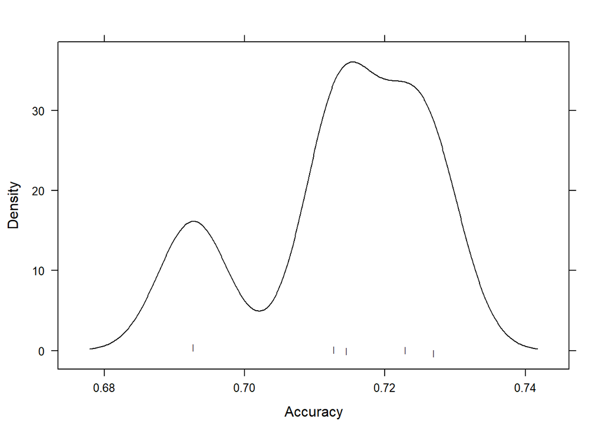

```r
densityplot(classlogit, pch = "|")                   #density plot
```

Overall in conclusion, the model performs stably when predicting training data and testing data with around 72% accuracy, derived from the confusion matrices above and overall, the accuracy rate tends to be 72% with distribution shown above.

## 3.4 Model 4: Random Forest

```r
train_control <- trainControl(method="cv", number=5,savePredictions = TRUE)#,summaryFunction=defaultSummary(trainData,trainData$DELAY))

library(caret)
#rfmodel<-train(profitability~., data=movie.train, trControl=train_control, method="rf",tuneLength=15)
```

```r
#saveRDS(rfmodel, file = "C:/Users/Linh/Documents/Y3 Sem 2/DSC4217/Group Project/New data cleaned/rfmodel1.rds")
rfmodel<-readRDS("C:/Users/Linh/Documents/Y3 Sem 2/DSC4217/Group Project/New data cleaned/rfmodel1.rds")
```

```r
print(rfmodel$finalModel)                     #print the final random forest model
```

```
##
## Call:
##  randomForest(x = x, y = y, mtry = param$mtry)
##                Type of random forest: classification
##                      Number of trees: 500
## No. of variables tried at each split: 24
##
##         OOB estimate of  error rate: 23.67%
## Confusion matrix:
##     0    1 class.error
## 0 921  363   0.2827103
## 1 304 1230   0.1981747
```

```r
rfmodel$resample                                 #reporting each fold performance
```

```
##    Accuracy     Kappa Resample
## 1 0.7553191 0.5036161    Fold3
## 2 0.7429078 0.4812494    Fold2
## 3 0.7500000 0.4949190    Fold5
## 4 0.7495560 0.4905043    Fold1
## 5 0.7584369 0.5143966    Fold4
```

Generally, when testing against 5 folds, the accuracy rate falls between 73% to 78% and Kappa falls between 46% and 56%.

```r
#Confusion matrix with test data
cm1<-as.matrix(table(predict(rfmodel,movie.test),movie.test$profitability))
cm1
```

```
##
##       0   1
##   0 262  69
##   1  97 273
```

```r
accuracy41<-(cm1[1,1]+cm1[2,2])/(cm1[1,1]+cm1[2,2]+cm1[1,2]+cm1[2,1])
accuracy41
```

```
## [1] 0.7631954
```

```r
#Confusion matrix with train data
cm2<-as.matrix(table(predict(rfmodel,movie.train),movie.train$profitability))
cm2
```

```
##
##        0    1
##   0 1284    0
##   1    0 1534
```

```r
accuracy42<-(cm2[1,1]+cm2[2,2])/(cm2[1,1]+cm2[2,2]+cm2[1,2]+cm2[2,1])
accuracy42
```

```
## [1] 1
```

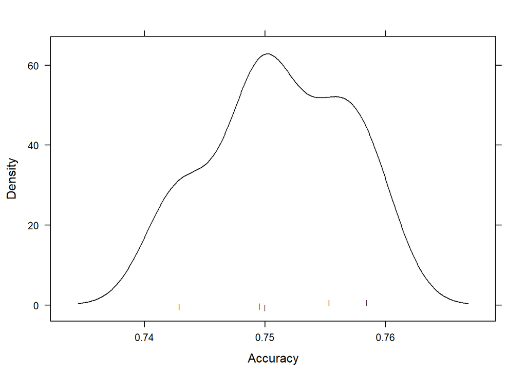

```r
densityplot(rfmodel, pch = "|")                   #density plot
```

## 3.5 Summary and conclusion

```r
# collect resamples
results <- resamples(list(dtree=classtree, ctree=classtree1 ,glm=classlogit,rf=rfmodel))
# summarize the distributions
summary(results)
```

```
##
## Call:
## summary.resamples(object = results)
##
## Models: dtree, ctree, glm, rf
## Number of resamples: 5
##
## Accuracy
##            Min.   1st Qu.    Median      Mean   3rd Qu.      Max. NA's
## dtree 0.6382979 0.6507092 0.6802842 0.6678615 0.6808511 0.6891652    0
## ctree 0.6666667 0.6790780 0.6879433 0.6927160 0.7003546 0.7295374    0
## glm   0.6927176 0.7127660 0.7145390 0.7139772 0.7229130 0.7269504    0
## rf    0.7429078 0.7495560 0.7500000 0.7512440 0.7553191 0.7584369    0
##
## Kappa
##            Min.   1st Qu.    Median      Mean   3rd Qu.      Max. NA's
## dtree 0.2736272 0.2961076 0.3386233 0.3282420 0.3647908 0.3680609    0
## ctree 0.3220374 0.3561319 0.3705437 0.3802329 0.3942344 0.4582171    0
## glm   0.3782262 0.4220800 0.4272775 0.4245329 0.4437675 0.4513133    0
## rf    0.4812494 0.4905043 0.4949190 0.4969371 0.5036161 0.5143966    0
```

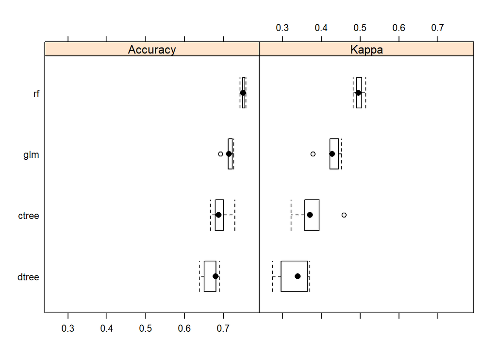

```r
# boxplots of results
bwplot(results)
```

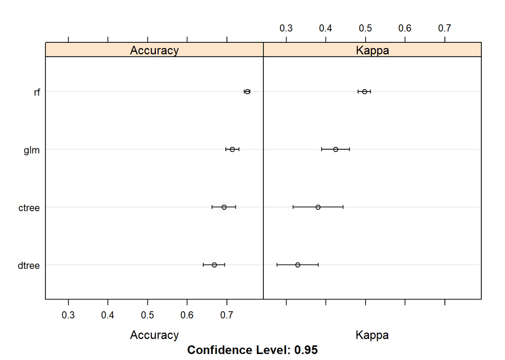

```r
# dot plots of results
dotplot(results)
```

```r
results.df<- data.frame(accuracy =c("testing","training"), classification_decision_tree = c(accuracy11,accuracy12),conditional_inference_tree = c(accuracy21,accuracy22), log_regression =  c(accuracy31,accuracy32), random_forest= c(accuracy41,accuracy42))
print(results.df)
```

```
##   accuracy classification_decision_tree conditional_inference_tree
## 1  testing                    0.6348074                  0.7089872
## 2 training                    0.6721079                  0.8229241
##   log_regression random_forest
## 1      0.7332382     0.7631954
## 2      0.7246274     1.0000000
```